# Linear Modeling

We’ll focus on inferential models today and build towards predictive models next week.

# What are models?

By a model, we mean a mathematical representation about the process that generated our observed data (aka data generation process). That is, how an outcome of interest (a response variable, dependent variable, $Y$) is related to (is a function of) one or more predictor (explanatory, independent, $X$) variables. For example,
$$Y = \beta_0 + \beta_1 X_1 + \beta_2 X_2 + \epsilon$$

where $Y$ is the outcome/response variable, $X_1$ and $X_2$ are the predictors/explanatory variables, $\beta_0$ and $\beta_1$ are coefficients to be estimated, and $\epsilon$ is random error (more below).

## What are linear models?

Linear models, or regression models, trace the the distribution of the dependent variable ($Y$) – or some characteristic of the distribution (the mean) – as a function of the independent variables ($X$s).In other words, the regression function/linear model is the curve determined by the conditional means (conditional expectation) of the response variable for fixed values of explanatory variables.

Using the SCI data, I’ve plotted the “peak size” of a displacement event as a function of state fragility – with fragility collapsed into bins.

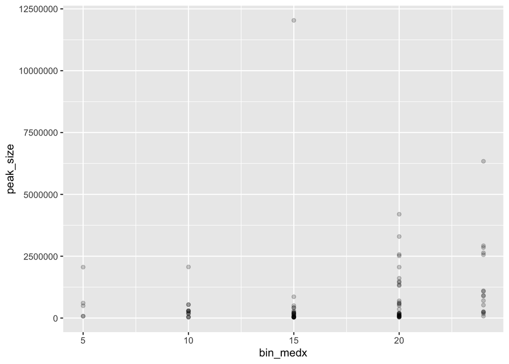

```r
# plot with bins
p <- ggplot(sci_tmp, aes(x = bin_medx, y = peak_size))
p + geom_point(alpha = 1/5)
```

This shows the conditional distribution of peak size. Let’s add the conditional mean for each category of fragility.

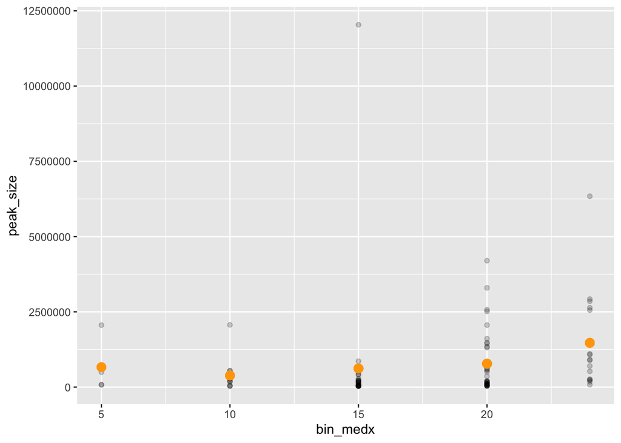

```r
# plot with conditional means
p + geom_point(alpha = 1/5) +
  geom_point(aes(x=bin_medx, y=bin_meany), color = "orange", size = 3)
```

If we connect these dots, we’ve traced the curve of the conditional mean of peak size.

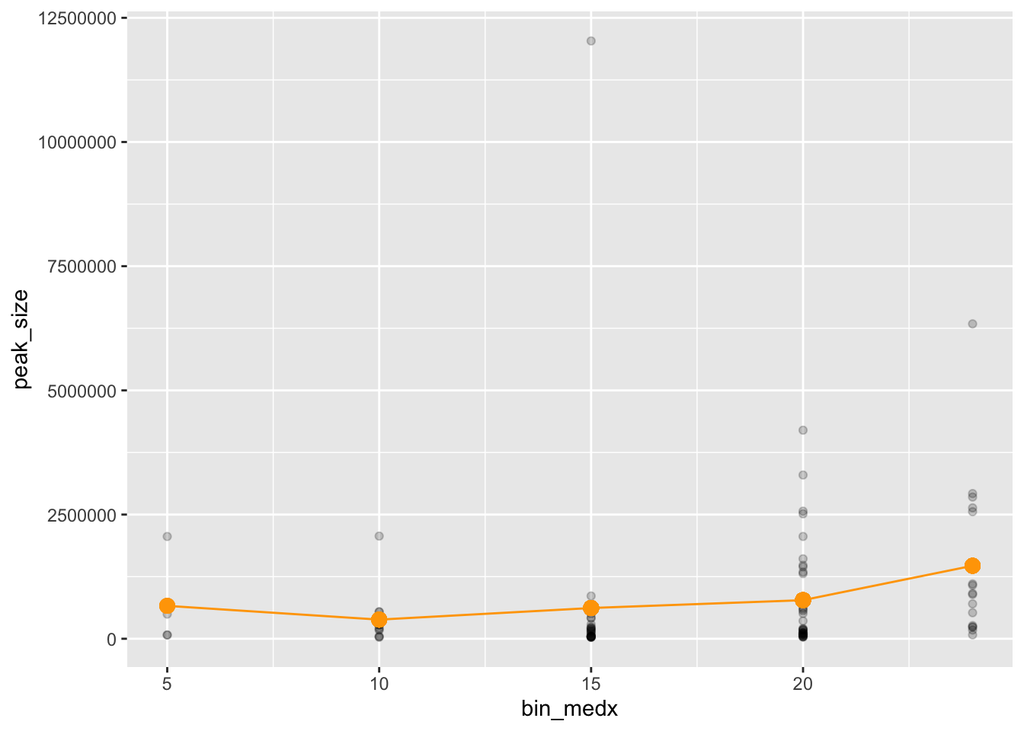

```r
# plot with line connecting conditional means
p + geom_point(alpha = 1/5) +
  geom_point(aes(x=bin_medx, y=bin_meany), color = "orange", size = 3) +
  geom_line(aes(x=bin_medx, y=bin_meany), color = "orange")
```

In linear regression analysis, we add the additional caveat that (the mean of) $Y$ is some **linear** function of $X$.

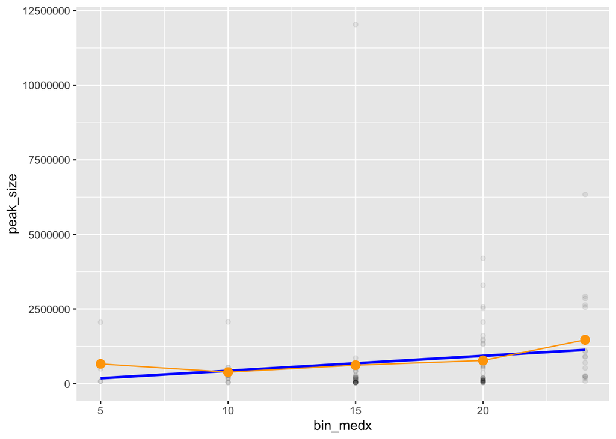

```r
# plot with regression line
p + geom_point(alpha = 1/15) +
  geom_smooth(method = "lm", se = FALSE, color = "blue") +
  geom_point(aes(x = bin_medx, y = bin_meany), color = "orange", size = 3) +
  geom_line(aes(x = bin_medx, y = bin_meany), color = "orange")
```

We represent the relationship mathematically
$$E(Y|X_i) = \beta_0 + \beta_1 X_1 + \beta_2 X_2$$

Here, $\beta_1$ represents the expected unit change in $Y$ for a unit change in $X_1$.

For example,

$$peak size = -69354 + 50121 * fragility$$

## Linearity

Linearity doesn’t necessarily imply that the curve connecting the mean of $Y$ conditional on values of $X$ is a straight line (though that is often what we impose), but that the *parameters* that describe the function relating $Y$ to the $X$s are linear. The equation is additive – the weights aren’t multipled or raised to a power other than 1.

This **is not** additive
$$E(Y|X_i) = \beta_0 + \beta_1 X_1^{\beta_2}$$

… and so **not** a linear model. But this is additive
$$E(Y|X_i) = \beta_0 + \beta_1 X_1 + \beta_2 X_2^2$$

… and so **is** a linear model, though not a straight line.

## Model error

Models are probabilistic, not deterministic.

- The regression tells us about the average (peak) displacement size for a given state context; any given event will deviate from the conditional expectation (conditional mean), much like an event’s size will deviate from the overall mean in the sample.
- Peak size isn’t perfectly predicted by fragility, or even fragility and a lot of other important variables.
- And if history was repeated, the peak size would vary from those we observe here.

No model will perfectly predict an outcome of interest, so regression models are largely about quantifying our uncertainty. The error term is meant to capture this stochastic element

## An aside (sort of)

All statistical models are extreme simplifications of complex social reality, not literal representations of the social processes by which outcomes are realized and observed.

Or, as George Box famously notes in his [1979 address to ASA](https://www-jstor-org.proxy01.its.virginia.edu/stable/2286713) (via UVA):

> Models, of course, are never true, but fortunately it is only necessary that they be useful. For this it is usually needful only that they not be grossly wrong.

More succintly, in [1987](https://search.lib.virginia.edu/catalog/u770409)

> All models are wrong, but some are useful.

Avoid reifying statistical models; they are descriptive summaries, not literal accounts of social processes.

## Residuals

$\epsilon$ is our random (stochastic) element, the error or disturbance term. It represents the deviation of a particular value of $Y_i$ from the conditional mean.
$$\epsilon_i = Y_i - E(Y|X_i)$$

Regression partitions variation in $Y$ into the systematic component (that accounted for by variation in $X$s) and the stochastic component (not explained).

Error is estimated by the residuals – the difference between the predicted value and actual value.

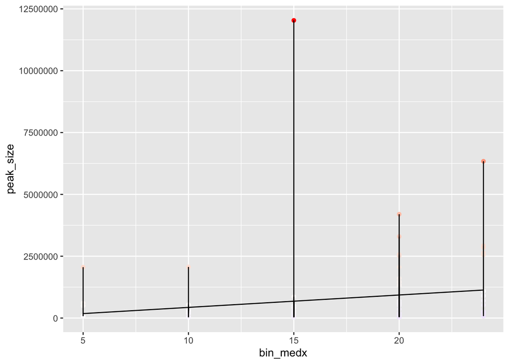

The model parameters are estimated to generate a mean residual value of 0. What we use the residuals to estimate, then, is the variance of the error, $\sigma^2_{\epsilon}$ – that is, how much a typical observation’s actual value deviates from the expected value.

Theoretically $\epsilon_i$ represents the aggregated omitted variables, measurement error in $Y$, and inherently random elements of $Y$.

## Estimation (briefly)

We (usually) estimate the regression coefficients (weights, parameters) by minimizing the residual sum of squares (RSS, or the squared-error loss function). This generates estimates that define a line as close to the actual data points as possible.

$$min \sum (\hat{\epsilon}_i)^2\\
min \sum(Y_i - \hat{Y}_i)^2\\
min \sum(Y_i - \hat{\beta}_0 + \hat{\beta}_1 X_i)^2$$

This **least-squares criterion** is a quadratic and symmetric function:

- Quadratic: deviations farther from the line are weighted more heavily by the squaring process so atypical observations can have a big effect on the placement of the line.
- Symmetric: deviations above the least-squares line and those below it are treated the same.

# Before you model

Explore and clean the data

- numbers are read as numbers; factors are read as factors
- values are in expected range
- how much missingness, how are missing obs coded
- how variables are distributed (histograms, density plots, etc.)
- how variables are related (bivariately)?

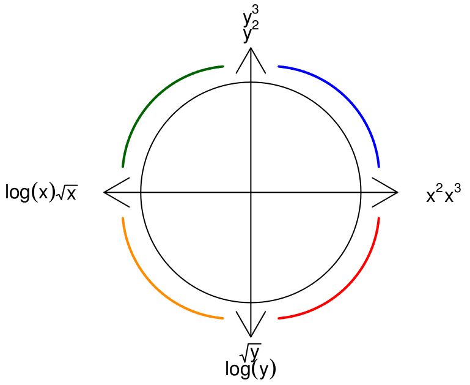

# Linear Models in R

## Implementation in R

To fit a linear model we propose a model and then estimate the coefficients and the standard deviation of the error term. For the model $Y = \beta_0 + \beta_1 X_1 + \beta_2 X_2 + \epsilon$, this means estimating $\beta_0$, $\beta_1$, $\beta_2$, and $\sigma$.

The basic function is `lm`; required arguments are `formula` and `data`.

`lm(Y ~ X1 + X2, data = mydata)`

```r
lm_peak <- lm(peak_size ~ fragility + pre_pop + pol_terror + polity + gdp_per + hdi,
              data = sci)
```

## Model summary

The saved linear model object contains various quantities of interest. Extractor functions provide those quantities.

```r
summary(lm_peak)
```

```
##
## Call:
## lm(formula = peak_size ~ fragility + pre_pop + pol_terror + polity +
##     gdp_per + hdi, data = sci)
##
## Residuals:
##      Min       1Q   Median       3Q      Max
## -1686478  -700250  -347253   339409  9710303
##
## Coefficients:
##               Estimate Std. Error t value Pr(>|t|)
## (Intercept) -2.970e+06  1.190e+06  -2.496  0.01441 *
## fragility    2.812e+04  3.873e+04   0.726  0.46970
## pre_pop     -4.261e-04  9.369e-04  -0.455  0.65038
## pol_terror   6.427e+05  1.980e+05   3.246  0.00165 **
## polity      -5.047e+04  3.123e+04  -1.616  0.10963
## gdp_per     -1.612e+02  8.689e+01  -1.856  0.06687 .
## hdi          2.168e+06  1.399e+06   1.550  0.12482
## ---
## Signif. codes:  0 '***' 0.001 '**' 0.01 '*' 0.05 '.' 0.1 ' ' 1
##
## Residual standard error: 1453000 on 88 degrees of freedom
##   (2 observations deleted due to missingness)
## Multiple R-squared:  0.1827, Adjusted R-squared:  0.1269
## F-statistic: 3.278 on 6 and 88 DF,  p-value: 0.005882
```

- **Call:** The model formula, useful if result is saved for later
- **Residuals:** A quick check of the distribution of residuals. Ideally, median is near 0, max and min, and 1Q and 3Q, are approximately equivalent.
- **Coefficients:**
  - **Estimate:** $\hat{\beta}$
  - **Std. error:** standard error of $\hat{\beta}$
  - **t value:** test statistic for $H_0: \hat{\beta} = 0$, calculated by $\left(\frac{estimate}{std. error}\right)$
  - $\mathbf{Pr(>|t|)}$: $p$-value of hypothesis test (2-sided)
  - **Signif. codes:** indicate statistical significance
- **Residual standard error:** $\hat{\sigma}$
- **degrees of freedom:** # of obs - # of estimated parameters
- **Multiple R-squared:** measure of model fit (0,1)
- **Adjusted R-squared:** measure of model fit adjusted for number of parameters (0,1)
- **F-statistic:** test statistic for hypothesis that all coefficients (other than intercept) simultaneously equal zero
- **p-value:** $p$-value for F-statistics

## Extraction and Effects

To extract specific quantities of interest:

```r
coef(lm_peak)
```

```
##   (Intercept)     fragility       pre_pop    pol_terror        polity
## -2.969540e+06  2.812085e+04 -4.260951e-04  6.427052e+05 -5.046813e+04
##       gdp_per           hdi
## -1.612247e+02  2.167989e+06
```

```r
confint(lm_peak)
```

```
##                     2.5 %        97.5 %
## (Intercept) -5.333595e+06 -6.054859e+05
## fragility   -4.884319e+04  1.050849e+05
## pre_pop     -2.288023e-03  1.435832e-03
## pol_terror   2.492576e+05  1.036153e+06
## polity      -1.125233e+05  1.158706e+04
## gdp_per     -3.338980e+02  1.144854e+01
## hdi         -6.123045e+05  4.948282e+06
```

```r
head(fitted(lm_peak))
```

```
##         1         2         3         4         5         6
## 1849837.7  860468.6 -738774.1  709598.9  970207.5 1703962.7
```

We can use ggeffects to show how $Y$ changes as an identified $X$ changes:

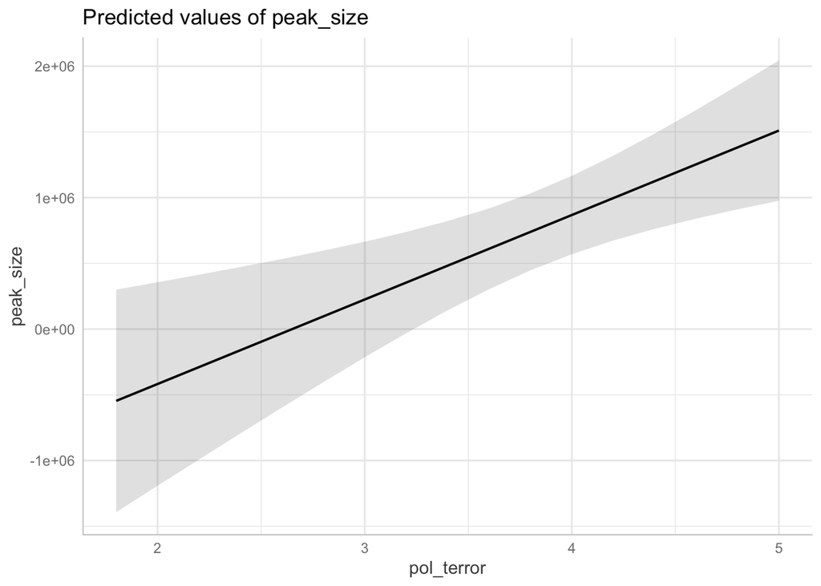

```r
plot(ggpredict(lm_peak, terms = c("pol_terror")))
```

And while variable importance in linear regression is generally based on the t value, we’ll see other non-parametric models where it’s not quite so simple. To help us see which predictors are influencing $Y$, we can use the vip function:

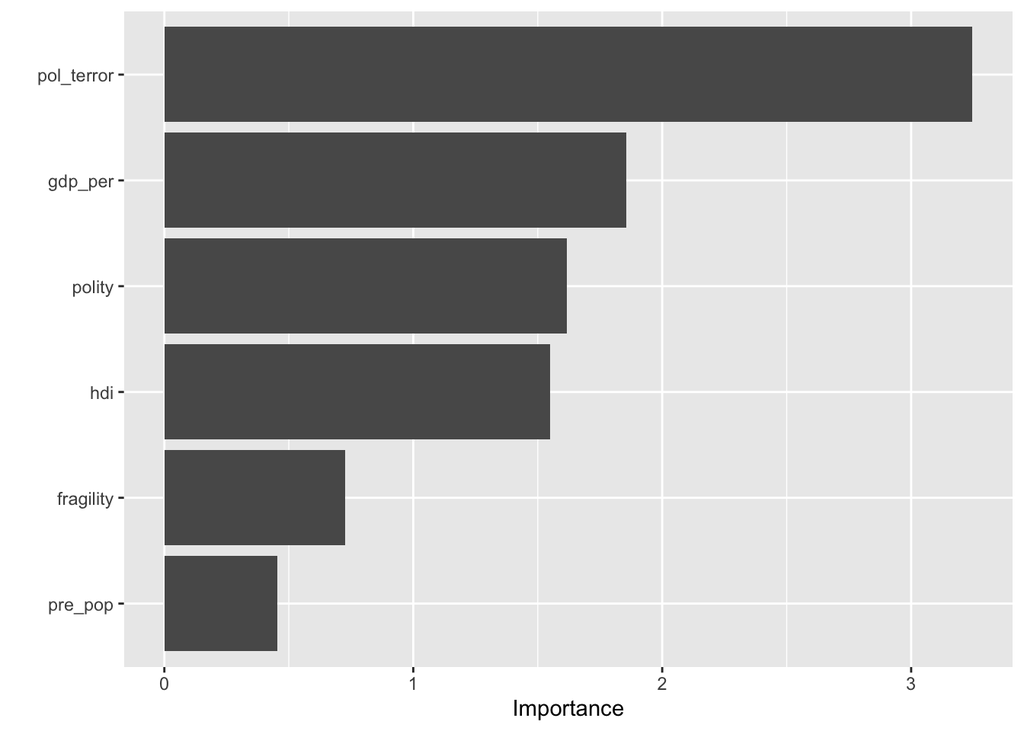

```r
vip(lm_peak)
```

## Specifying Models

R uses the Wilkinson-Rogers notation for specifying models:

`response variable ~ explanatory variables`

The tilde (~) is read as “is modelled as a function of” or “regressed on.” Additional model symbols are include:

- `+` inclusion of variable
- `-` exclusion of variable (not subtraction)
- `∗` include variables and their interactions

And variables can be wrapped in functions in the model. Some examples

- `y ~ x1 + x2 + x3` (multiple regression)
- `y ~ .` (regress y on all variables in data set)
- `y ~ x1 + x2 - 1` (exclude intercept)
- `y ~ x1 * x2` (interact x1 and x2)
- `y ~ poly(x1, 2) + x3` (polynomial regresion)

## An Aside on Visualizing Correlation Matrices

It can be useful, as well, to understand the relations in your predictor variables.

```r
# create a subset of the data used in the model above
sci_tmp <- sci %>%
  select(peak_size, fragility, pre_pop, pol_terror, polity, gdp_per, hdi) %>%
  drop_na

cor_mat <- cor(sci_tmp) # generate a correlation matrix
cor_mat
```

```
##               peak_size  fragility      pre_pop   pol_terror      polity
## peak_size   1.000000000  0.1383954 -0.056491804  0.321427686 -0.21788456
## fragility   0.138395450  1.0000000 -0.103623472  0.150209358 -0.34950305
## pre_pop    -0.056491804 -0.1036235  1.000000000  0.009784038  0.13423533
## pol_terror  0.321427686  0.1502094  0.009784038  1.000000000 -0.07476352
## polity     -0.217884558 -0.3495030  0.134235333 -0.074763525  1.00000000
## gdp_per    -0.105689665 -0.3166116  0.029236514  0.216612992  0.23903981
## hdi         0.002468119 -0.6438417  0.109498047  0.043500602  0.31222456
##                gdp_per          hdi
## peak_size  -0.10568966  0.002468119
## fragility  -0.31661161 -0.643841661
## pre_pop     0.02923651  0.109498047
## pol_terror  0.21661299  0.043500602
## polity      0.23903981  0.312224565
## gdp_per     1.00000000  0.505805377
## hdi         0.50580538  1.000000000
```

If the predictors are highly correlated, regression can’t parse the variation in $Y$ due to one $X$ versus another. The correlation plot represents the relationships visually.

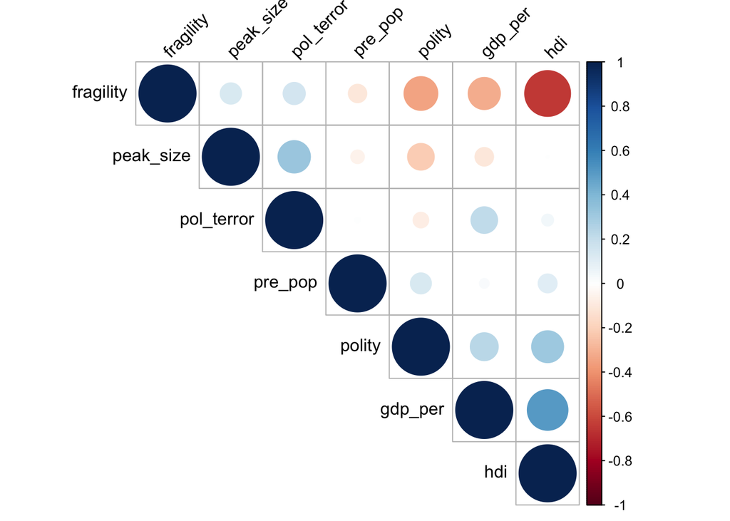

```r
corrplot(cor_mat, type = "upper", order = "hclust", tl.col = "black", tl.srt = 45)
```

Also a heatmap

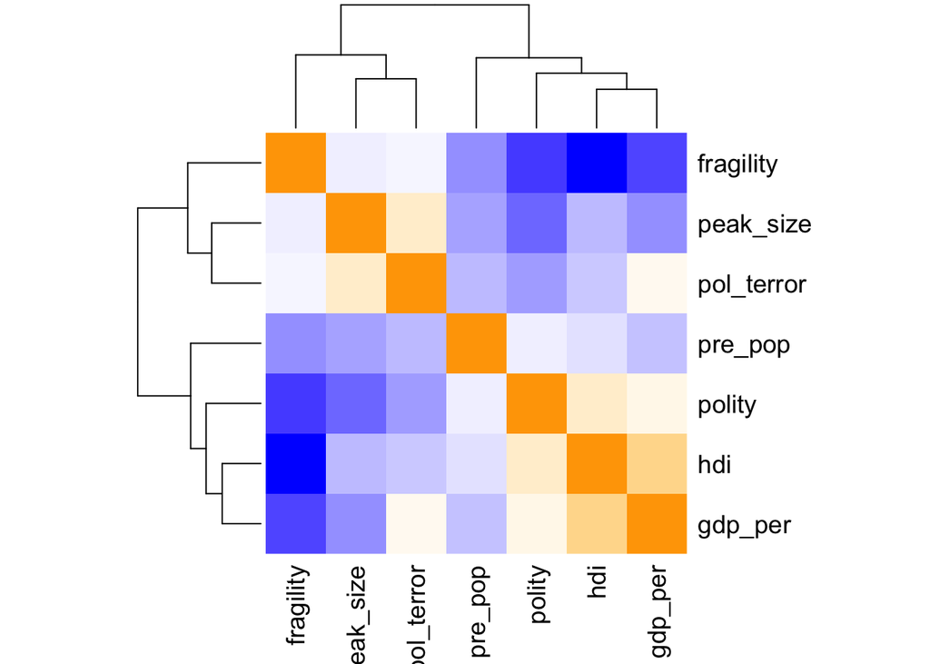

```r
col <- colorRampPalette(c("blue", "white", "orange"))(100)
heatmap(x = cor_mat, col = col, symm = TRUE)
```

## Factors

For inclusion in a model, R requires categorical predictors – like conflict type or ethnic composition – to be encoded as factors. By default, coefficients for factors are modeled using treatment contrasts – one level is treated as the baseline and the other levels have coefficients that express differences from that baseline. For example, let’s add conflict type.

```r
lm_peak_fct <- lm(peak_size ~ fragility + pol_terror + polity + gdp_per + hdi + conflict_type,
              data = sci)
summary(lm_peak_fct)
```

```
##
## Call:
## lm(formula = peak_size ~ fragility + pol_terror + polity + gdp_per +
##     hdi + conflict_type, data = sci)
##
## Residuals:
##      Min       1Q   Median       3Q      Max
## -1659410  -732093  -332637   410965  9850177
##
## Coefficients:
##                                         Estimate Std. Error t value
## (Intercept)                           -3.181e+06  1.323e+06  -2.404
## fragility                              3.208e+04  3.990e+04   0.804
## pol_terror                             6.347e+05  2.118e+05   2.997
## polity                                -5.072e+04  3.263e+04  -1.554
## gdp_per                               -1.589e+02  8.935e+01  -1.778
## hdi                                    2.251e+06  1.436e+06   1.568
## conflict_typeIndependence              7.903e+04  8.450e+05   0.094
## conflict_typeInterstate               -7.618e+04  7.272e+05  -0.105
## conflict_typeMultiple civil conflicts  1.264e+05  4.206e+05   0.300
## conflict_typeMultiple conflicts        2.522e+05  3.787e+05   0.666
##                                       Pr(>|t|)
## (Intercept)                            0.01839 *
## fragility                              0.42366
## pol_terror                             0.00357 **
## polity                                 0.12384
## gdp_per                                0.07893 .
## hdi                                    0.12068
## conflict_typeIndependence              0.92571
## conflict_typeInterstate                0.91682
## conflict_typeMultiple civil conflicts  0.76458
## conflict_typeMultiple conflicts        0.50723
## ---
## Signif. codes:  0 '***' 0.001 '**' 0.01 '*' 0.05 '.' 0.1 ' ' 1
##
## Residual standard error: 1475000 on 85 degrees of freedom
##   (2 observations deleted due to missingness)
## Multiple R-squared:  0.186,  Adjusted R-squared:  0.09978
## F-statistic: 2.158 on 9 and 85 DF,  p-value: 0.03303
```

## Interactions

Inclusion of a factor variable tests for varying intercepts between categories, but assumes any numerical variables influence the outcome variable for each category in the same way – e.g., the baseline peak size under multiple conflicts may be higher, but the relation between peak size and the political terror scale is the same across all conflict types.

If, instead, the effect of a variable *depends* on another variable – e.g., the effect of political terror on peak size depends on the type of conflict – we say the variables interact. Interactions are one way of expressing potential causal heterogeneity, when an outcome is structured differently for different types of observations.

```r
lm_peak_int <- lm(peak_size ~ fragility*conflict_type + pol_terror + polity + gdp_per + hdi,
                  data = sci)
summary(lm_peak_int)
```

```
##
## Call:
## lm(formula = peak_size ~ fragility * conflict_type + pol_terror +
##     polity + gdp_per + hdi, data = sci)
##
## Residuals:
##      Min       1Q   Median       3Q      Max
## -1954402  -717391  -285886   329143  9701012
##
## Coefficients:
##                                                   Estimate Std. Error
## (Intercept)                                     -2.159e+06  1.551e+06
## fragility                                       -2.191e+04  5.388e+04
## conflict_typeIndependence                       -8.553e+05  2.213e+06
## conflict_typeInterstate                          6.704e+05  2.319e+06
## conflict_typeMultiple civil conflicts           -1.526e+06  1.370e+06
## conflict_typeMultiple conflicts                 -1.424e+06  1.156e+06
## pol_terror                                       5.900e+05  2.182e+05
## polity                                          -5.103e+04  3.338e+04
## gdp_per                                         -1.542e+02  9.464e+01
## hdi                                              2.246e+06  1.450e+06
## fragility:conflict_typeIndependence              5.634e+04  1.467e+05
## fragility:conflict_typeInterstate               -5.384e+04  1.456e+05
## fragility:conflict_typeMultiple civil conflicts  1.081e+05  8.598e+04
## fragility:conflict_typeMultiple conflicts        1.085e+05  7.057e+04
##                                                 t value Pr(>|t|)
## (Intercept)                                      -1.392  0.16759
## fragility                                        -0.407  0.68538
## conflict_typeIndependence                        -0.387  0.70011
## conflict_typeInterstate                           0.289  0.77329
## conflict_typeMultiple civil conflicts            -1.114  0.26877
## conflict_typeMultiple conflicts                  -1.232  0.22141
## pol_terror                                        2.704  0.00835 **
## polity                                           -1.529  0.13025
## gdp_per                                          -1.629  0.10719
## hdi                                               1.549  0.12539
## fragility:conflict_typeIndependence               0.384  0.70193
## fragility:conflict_typeInterstate                -0.370  0.71250
## fragility:conflict_typeMultiple civil conflicts   1.257  0.21228
## fragility:conflict_typeMultiple conflicts         1.537  0.12811
## ---
## Signif. codes:  0 '***' 0.001 '**' 0.01 '*' 0.05 '.' 0.1 ' ' 1
##
## Residual standard error: 1477000 on 81 degrees of freedom
##   (2 observations deleted due to missingness)
## Multiple R-squared:  0.2226, Adjusted R-squared:  0.09786
## F-statistic: 1.784 on 13 and 81 DF,  p-value: 0.05961
```

Here we have varying intercepts and varying slopes. We can have interactions between two factors, between a factor and numeric variable (as above), between two numeric variables, between three variables! And polynomial regression, where a predictor is included as a squared or cubed (or higher exponent) term, works the same way – with a variable interacted with itself.

And we can create an effects plot to help see the estimated interaction (we’ll throw in a variance important plot while we’re at it).

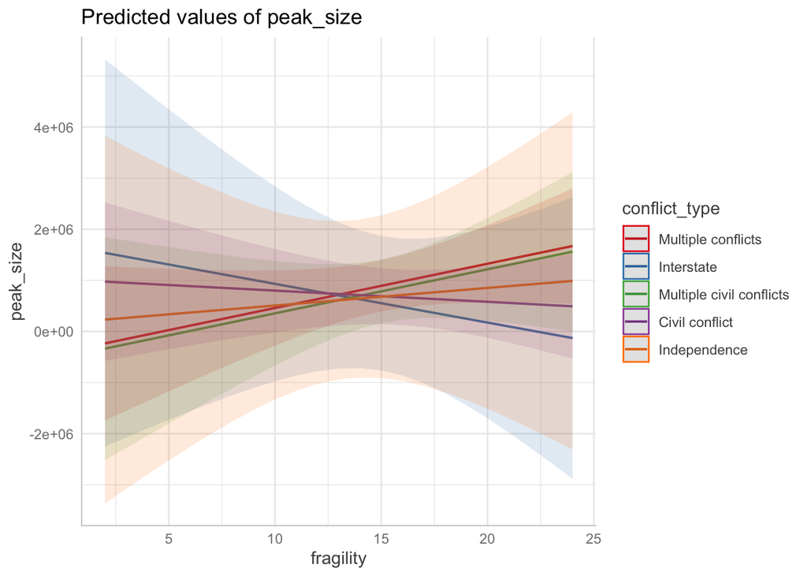

```r
# effect plot
plot(ggpredict(lm_peak_int, terms = c("fragility", "conflict_type")))
```

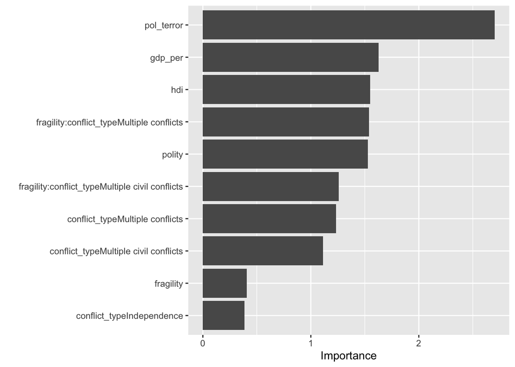

```r
# variable importance plot
vip(lm_peak_int)
```

## Nonlinearities

If data exploration suggested relationships aren’t reasonably linear, transformations of the variables can accommodate a variety of nonlinearities. Logs and polynomials are the most widely used.

Adding a squared X term:

```r
lm_peak_poly <- lm(peak_size ~ fragility + poly(pol_terror, 2, raw = TRUE) + polity + gdp_per + hdi,
                 data = sci)
summary(lm_peak_poly)
```

```
##
## Call:
## lm(formula = peak_size ~ fragility + poly(pol_terror, 2, raw = TRUE) +
##     polity + gdp_per + hdi, data = sci)
##
## Residuals:
##      Min       1Q   Median       3Q      Max
## -1973760  -573899  -275466   102221  9447468
##
## Coefficients:
##                                    Estimate Std. Error t value Pr(>|t|)
## (Intercept)                       2.713e+06  3.062e+06   0.886   0.3781
## fragility                         2.857e+04  3.790e+04   0.754   0.4529
## poly(pol_terror, 2, raw = TRUE)1 -2.454e+06  1.552e+06  -1.581   0.1175
## poly(pol_terror, 2, raw = TRUE)2  4.147e+05  2.064e+05   2.009   0.0476 *
## polity                           -4.193e+04  3.081e+04  -1.361   0.1769
## gdp_per                          -1.611e+02  8.497e+01  -1.896   0.0613 .
## hdi                               1.767e+06  1.380e+06   1.281   0.2036
## ---
## Signif. codes:  0 '***' 0.001 '**' 0.01 '*' 0.05 '.' 0.1 ' ' 1
##
## Residual standard error: 1422000 on 88 degrees of freedom
##   (2 observations deleted due to missingness)
## Multiple R-squared:  0.2167, Adjusted R-squared:  0.1633
## F-statistic: 4.057 on 6 and 88 DF,  p-value: 0.001229
```

Here intrepretation begins to get more complicated. The effects plot can help

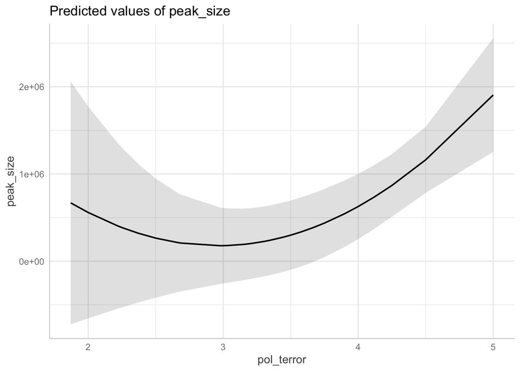

```r
plot(ggpredict(lm_peak_poly, terms = c("pol_terror")))
```

Adding splines (and generating effects plot):

```r
lm_peak_spl <- lm(peak_size ~ fragility + ns(pol_terror, df = 2) + polity + gdp_per + hdi,
                  data = sci)
summary(lm_peak_spl)
```

```
##
## Call:
## lm(formula = peak_size ~ fragility + ns(pol_terror, df = 2) +
##     polity + gdp_per + hdi, data = sci)
##
## Residuals:
##      Min       1Q   Median       3Q      Max
## -1980025  -576767  -273515   125646  9431464
##
## Coefficients:
##                           Estimate Std. Error t value Pr(>|t|)
## (Intercept)             -558711.84 1207768.75  -0.463 0.644794
## fragility                 28107.59   37882.50   0.742 0.460083
## ns(pol_terror, df = 2)1  357703.75 1353947.54   0.264 0.792249
## ns(pol_terror, df = 2)2 1773173.17  461055.16   3.846 0.000227 ***
## polity                   -41185.04   30845.89  -1.335 0.185259
## gdp_per                    -163.31      84.95  -1.922 0.057787 .
## hdi                     1789245.38 1377459.47   1.299 0.197356
## ---
## Signif. codes:  0 '***' 0.001 '**' 0.01 '*' 0.05 '.' 0.1 ' ' 1
##
## Residual standard error: 1421000 on 88 degrees of freedom
##   (2 observations deleted due to missingness)
## Multiple R-squared:  0.2174, Adjusted R-squared:  0.1641
## F-statistic: 4.075 on 6 and 88 DF,  p-value: 0.001186
```

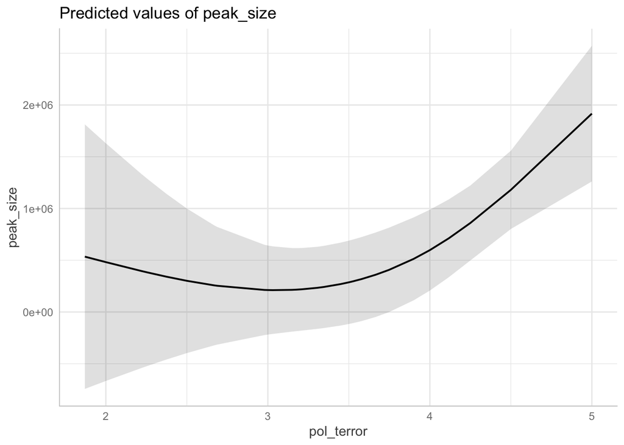

```r
plot(ggpredict(lm_peak_spl, terms = c("pol_terror")))
```

Logging Y:

```r
lm_peak_log <- lm(log(peak_size) ~ fragility + pol_terror + polity + gdp_per + hdi,
                  data = sci)
summary(lm_peak_log)
```

```
##
## Call:
## lm(formula = log(peak_size) ~ fragility + pol_terror + polity +
##     gdp_per + hdi, data = sci)
##
## Residuals:
##      Min       1Q   Median       3Q      Max
## -2.84649 -1.03736 -0.02995  0.89376  2.85297
##
## Coefficients:
##               Estimate Std. Error t value Pr(>|t|)
## (Intercept)  9.547e+00  1.083e+00   8.814 9.13e-14 ***
## fragility    3.069e-02  3.525e-02   0.870  0.38639
## pol_terror   6.103e-01  1.802e-01   3.387  0.00105 **
## polity      -4.575e-02  2.828e-02  -1.618  0.10927
## gdp_per     -8.324e-05  7.904e-05  -1.053  0.29513
## hdi          3.447e-01  1.272e+00   0.271  0.78703
## ---
## Signif. codes:  0 '***' 0.001 '**' 0.01 '*' 0.05 '.' 0.1 ' ' 1
##
## Residual standard error: 1.323 on 89 degrees of freedom
##   (2 observations deleted due to missingness)
## Multiple R-squared:  0.1943, Adjusted R-squared:  0.1491
## F-statistic: 4.293 on 5 and 89 DF,  p-value: 0.00152
```

```r
coef(lm_peak_log) %>% exp() %>% round(3)
```

```
## (Intercept)   fragility  pol_terror      polity     gdp_per         hdi
##   14002.225       1.031       1.841       0.955       1.000       1.412
```

So much easier to see what’s going on with an effects plot, though:

```
## Model has log-transformed response. Back-transforming predictions to original response scale. Standard errors are still on the log-scale.
```

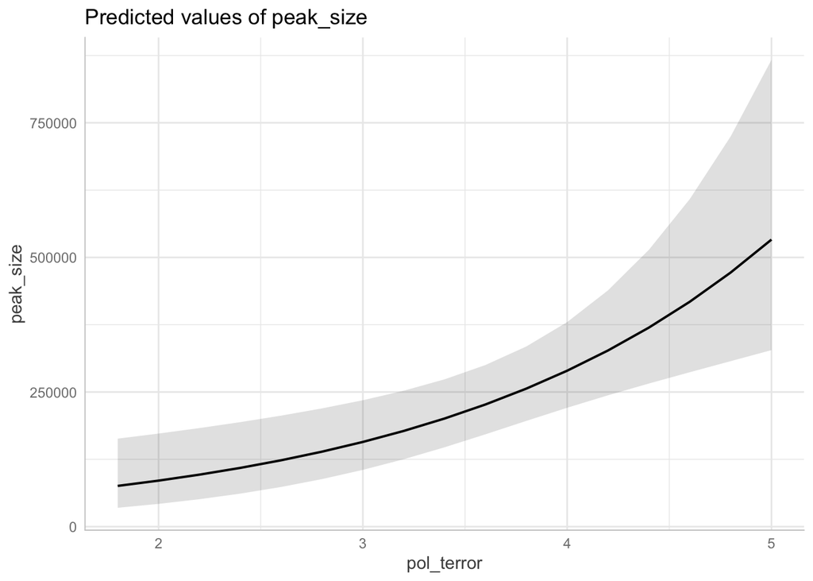

```r
plot(ggpredict(lm_peak_log, terms = c("pol_terror")))
```

## Model evaluation

For predictive models, we’ll use cross-validation for model evaluation (over things like $R^2$ or AIC for model fit, or error diagnostics for model specification). Estimate, diagnose, build the model with a subset of your sample, and proceed with inference by estimating the “good” model on the remainder of your data. We’ll hold on that until next week.

But in the meantime, let’s look at the AIC/BIC (information criteria, lower = better):

```r
AIC(lm_peak, lm_peak_fct, lm_peak_int, lm_peak_poly, lm_peak_spl, lm_peak_log)
```

```
##              df       AIC
## lm_peak       8 2974.2004
## lm_peak_fct  11 2979.8159
## lm_peak_int  15 2983.4384
## lm_peak_poly  8 2970.1642
## lm_peak_spl   8 2970.0729
## lm_peak_log   7  330.5413
```

```r
BIC(lm_peak, lm_peak_fct, lm_peak_int, lm_peak_poly, lm_peak_spl, lm_peak_log)
```

```
##              df       BIC
## lm_peak       8 2994.6314
## lm_peak_fct  11 3007.9085
## lm_peak_int  15 3021.7466
## lm_peak_poly  8 2990.5952
## lm_peak_spl   8 2990.5039
## lm_peak_log   7  348.4185
```

But wait! only models with same $Y$ value can be compared this way.

Let’s look at it another way – getting closer to what we’ll ultimately care about in predictive modeling: How well does the model generate outcomes like those we observe?

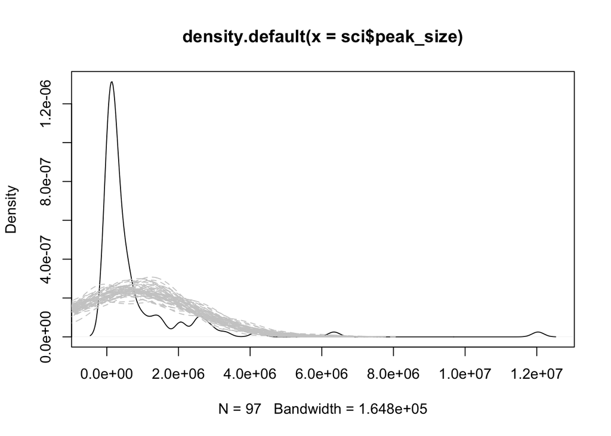

```r
sim_peak <- simulate(lm_peak, nsim = 50) # generate 50 simulated outcome vectors

plot(density(sci$peak_size)) # the density of y (using base R plot)
lines(density(sim_peak$sim_1), col = "grey80") # the outcomes simulated from the model
for(i in 1:50)lines(density(sim_peak[[i]]), lty = 2, col = "grey80") # all 50 simulations
```

That’s pretty bad! Let’s look at the model with the lowest AIC and BIC:

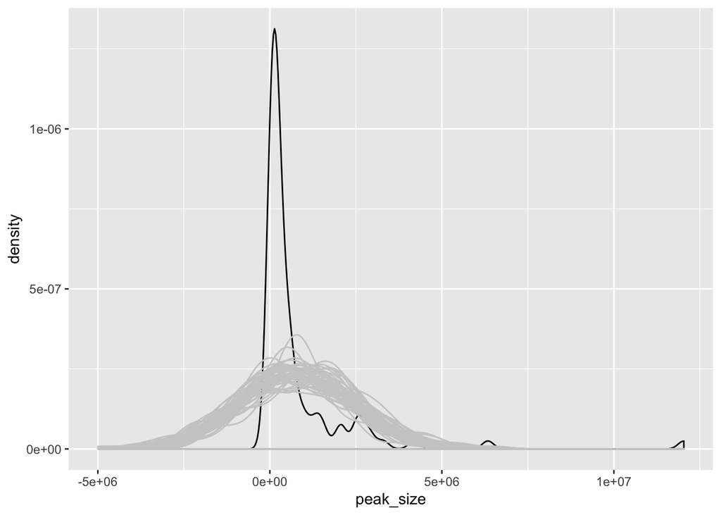

```r
sim_peak_spl <- simulate(lm_peak_spl, nsim = 50)

ggplot(sci, aes(x = peak_size)) + # we'll use ggplot this time
  geom_density() +
  geom_density(aes(x = peak_size, group = sim),
               pivot_longer(sim_peak_spl, everything(),
                            names_to = "sim",
                            values_to = "peak_size"),
               color = "grey80")
```

Still very poor. How about the model on logged $Y$?

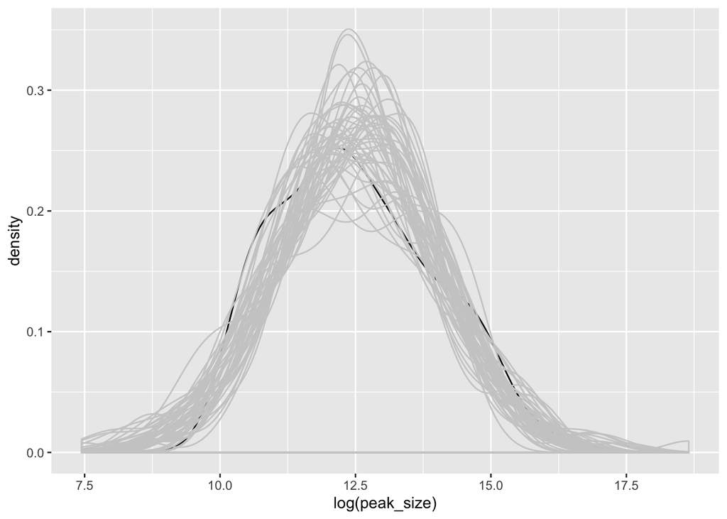

```r
sim_peak_log <- simulate(lm_peak_log, nsim = 50)

ggplot(sci, aes(x = log(peak_size))) +
  geom_density() +
  geom_density(aes(x = peak_size, group = sim),
               pivot_longer(sim_peak_log, everything(),
                            names_to = "sim",
                            values_to = "peak_size"),
               color = "grey80")
```

Getting closer – if peak displacement/scale is an outcome we want to model, a transformation might be useful (under the regression framework).

Nota Bene

## Interpretation and visualization

**Interpretation:** In multiple regression the coefficient represents the amount of change in $Y$ for a unit change in each predictor, *holding all other included variables contant*. That is, interpretation proceeds as if one predictor could change with no other variables changing.

**Visualization:** models are often best conveyed visually. The `broom` package tidies model summaries into a `tibble` that we can plot.

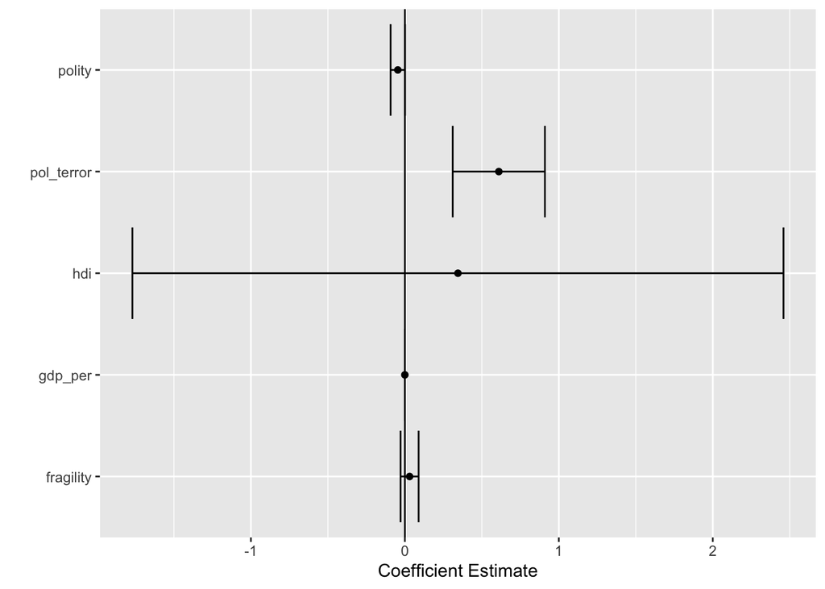

```r
tidy_peak <- tidy(lm_peak_log, conf.int = TRUE, conf.level = 0.9)

ggplot(tidy_peak[2:6,], aes(x = estimate, y = term,
                      xmin = conf.low,
                      xmax = conf.high)) +
  geom_point() +
  geom_vline(xintercept = 0) +
  geom_errorbarh() +
  labs(x = "Coefficient Estimate", y = "")
```

# Regression as Machine Learning

We’ve been using regression as a statistical model; it is also one of the more widely used machine learning algorithms.

## Machine learning

As mathematical representations, statistical models and machine learning algorithms are often indistinguishable. In practice, they tend to be used differently. Machine learning focuses on data-driven prediction, whereas statistical modeling focuses on theory-driven knowledge discovery.

Machine learning algorithms learn a target function ($f$) that best maps input variables ($X$) to an output variable ($Y$) – $Y = f(X)$ – in order to make predictions of $Y$ for new $X$, aka predictive modeling/analytics. The goal is to maximize prediction accuracy/minimize model error, without reference to explainability (or theory, hypotheses).

| Statistical models | Machine learning models |
| --- | --- |
| Theory driven | Data driven |
| Explanation | Prediction |
| Researcher-curated data | Combination of curated, machine-generated data |
| Evaluation via goodness of fit | Evaluation via prediction accuracy |

## Some additional definitions

- **RMSE:** Root Mean Squared Error, measures the average prediction error made by the model; i.e., the average difference between the observed outcome values and the values predicted by the model.
- **Cross validation:** split data into a training set and test set; build/learn the model on the training set; calculate RMSE/prediction error of the model using the test/held-out data.
- **$k$-fold cross validation:** divide data into $k$ sets, hold out 1 set and fit model with remaining $k-1$ sets; calculate RMSE/prediction error on the held-out data; repeat with each $k$ set; take average RMSE across $k$.

# Friends of the Linear Model

Many models expand on the basic linear regression model

- Genearlized linear models (e.g., logit, poisson, multinomial, etc.)
- Mixed effects models (random coefficients, hierarchical models)
- Penalized regression (shrinkage or regulariziation, e.g., Ridge, Lasso, ElasticNet)
- and more!

# Resources

- Garrett Grolemund and Hadley Wickham. 2018. [R for Data Science](https://r4ds.had.co.nz/model-intro.html), Chapters 22-25
- James, G., et al. 2013. [An Introduction to Statistical Learning.](http://www-bcf.usc.edu/~gareth/ISL/) New York: Springer.